# Factor Analysis for Business Decision-Making Using R

Data Analysis for Decision-Making (WS 2026) · Prof. Dr. Stephan Huber

Amal Gurbanov (Matr. Nr. 401491824)

gurbanov.amal@stud.hs-fresenius.de

Fresenius University of Applied Science

December 16, 2026

## The business problem

An online shop asks **400 customers** to rate **12 statements** (1 = strongly disagree … 7 = strongly agree). *Data are simulated for teaching.*

| Product | Service | Price |
| --- | --- | --- |
| quality, durability, design, variety | delivery, support, returns, communication | price fair, discounts, value, cheaper than rivals |

**Question for management:** Which *few* things really drive customer satisfaction, and where should we invest?

Twelve questions → twelve decisions? **No.** We need fewer, meaningful dimensions.

## What is factor analysis?

- Many observed variables are explained by a few hidden **latent factors** (Hair et al., 2019; Spearman, 1904)

*x*<sub>j</sub> = λ<sub>j1</sub> *F*<sub>1</sub> + … + λ<sub>jm</sub> *F*<sub>m</sub> + ε<sub>j</sub>

- λ = **loading**: how strongly an item belongs to a factor
- **EFA vs. PCA:** PCA summarises *all* variance; EFA models only the *shared* variance (Fabrigar et al., 1999)

## Workflow in six steps

1. **Check data**: size, missing values, n ≥ 100–200
2. **Suitability**: KMO > 0.6, Bartlett’s test significant
3. **How many factors?** Parallel analysis (Horn, 1965)
4. **Extract & rotate**: ML + oblimin (factors may correlate)
5. **Interpret & name** the factors (loadings > 0.3–0.4)
6. **Use** the results: reliability, factor scores → decisions

Thresholds are **rules of thumb**, not strict laws · all in R package `psych` (Revelle, 2026)

## Step 1–2: Is the data suitable?

```r
library(psych)
survey <- read.csv("data/customer_survey.csv")
items  <- survey[, 1:12]          # the 12 rating items
dim(items)                        # 400 customers, 12 items
```

```
[1] 400  12
```

```r
sum(is.na(items))                 # no missing values
```

```
[1] 0
```

```r
KMO(items)$MSA                    # rule of thumb: > 0.6
```

```
[1] 0.7901796
```

```r
cortest.bartlett(cor(items), n = nrow(items))$p.value
```

```
[1] 4.905772e-257
```

✅ KMO ≈ 0.79 (above 0.6) and Bartlett’s *p* < .001 → items are correlated enough.

## Step 3: How many factors?

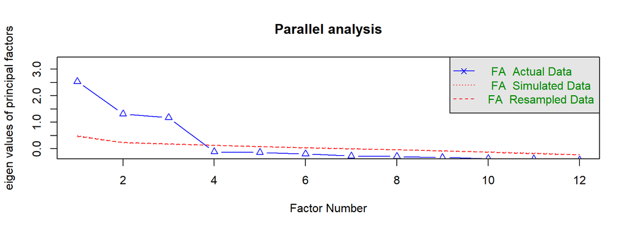

```
Parallel analysis suggests that the number of factors =  3  and the number of components =  NA
```

```r
set.seed(1)
pa <- fa.parallel(items, fa = "fa", main = "Parallel analysis")
```

Keep factors whose eigenvalue is **above the random-data line** → **3 factors**.

## Step 4: Extract and rotate

```r
fit <- fa(items, nfactors = 3, rotate = "oblimin", fm = "ml")
L <- unclass(fa.sort(fit)$loadings)       # sorted loadings
L[abs(L) < 0.3] <- NA                     # hide small loadings
print(round(L, 2), na.print = "")
```

```
                     ML1  ML3  ML2
price_fair          0.82
value               0.77
discounts           0.70
cheaper_than_rivals 0.50
support                  0.78
delivery                 0.70
returns                  0.68
communication            0.60
quality                       0.76
design                        0.74
durability                    0.70
variety                       0.56
```

## Robustness: is ML okay for Likert items?

Likert items are ordinal → check with **principal axis** and **polychoric** correlations:

```r
fit_pa   <- fa(items, nfactors = 3, rotate = "oblimin", fm = "pa")
fit_poly <- fa(items, nfactors = 3, rotate = "oblimin", cor = "poly")
round(factor.congruence(fit, fit_pa), 2)     # 1 = identical factor
```

```
    PA3  PA1  PA2
ML1   1 0.00 0.00
ML3   0 1.00 0.02
ML2   0 0.02 1.00
```

```r
round(factor.congruence(fit, fit_poly), 2)
```

```
      MR3  MR1  MR2
ML1  1.00 0.00 0.00
ML3 -0.01 1.00 0.02
ML2  0.00 0.02 1.00
```

Congruence ≈ 1.00 → the **same three factors** with every method → results are robust.

## Step 5: Interpret and name

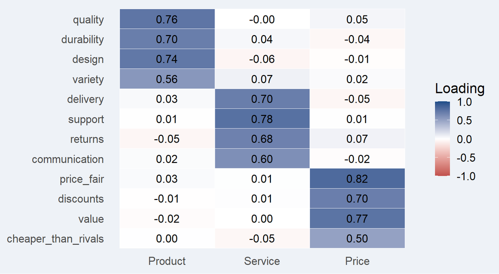

Each item loads strongly on **one** factor only → a clean, easy-to-name structure.

## Step 6: From factors to a decision

```r
L <- unclass(fit$loadings)
markers <- c(Product = "quality", Service = "support", Price = "price_fair")
scores <- as.data.frame(fit$scores)
# name each factor after its clearest item (step 5)
colnames(scores) <- names(markers)[apply(abs(L[markers, colnames(scores)]), 2, which.max)]
model <- lm(survey$satisfaction ~ Product + Service + Price, data = scores)
res <- summary(model)$coefficients
data.frame(b = round(res[, 1], 2), p = format.pval(res[, 4], eps = 0.001, digits = 2))
```

```
               b      p
(Intercept) 6.05 <0.001
Product     0.39 <0.001
Service     0.89 <0.001
Price       0.17  0.014
```

**Result:** Service is most strongly **associated** with satisfaction (simulated, cross-sectional data → not proof of causality). **Recommendation:** prioritise **delivery, support, returns** and test the effect in a pilot before investing.

## Where is it used in business?

- **Marketing:** drivers of satisfaction, SERVQUAL (Parasuraman et al., 1988)
- **HR:** employee engagement surveys
- **Finance:** common risk factors behind stock returns

**Pitfalls**

- Bad questions → bad factors
- Not only “eigenvalue > 1” (Costello & Osborne, 2005)
- Names are interpretations → confirm with CFA

## Exercise (≈ 15 minutes)

The data set `bfi` in `psych` contains **25 personality items** from 2,800 people (Goldberg, 1999).

```r
install.packages(c("psych", "GPArotation"))   # only once
library(psych)
big5 <- na.omit(bfi[, 1:25])    # complete answers only (n = 2,436)
```

1. Check suitability with `KMO()` and `cortest.bartlett()`.
2. Use `fa.parallel()`: how many factors are suggested?
3. Run `fa()` with **5 factors**, `rotate = "oblimin"`.
4. Which items load on which factor? Name the factors (look at `?bfi`).
5. **Business question:** How could an HR department use these factors?

## Exercise: solution (1/2)

```r
big5 <- na.omit(bfi[, 1:25])
KMO(big5)$MSA
```

```
[1] 0.8486452
```

```r
format.pval(cortest.bartlett(cor(big5), n = nrow(big5))$p.value, eps = 0.001)
```

```
[1] "< 0.001"
```

```r
set.seed(1)
fa.parallel(big5, fa = "fa", plot = FALSE)$nfact
```

```
Parallel analysis suggests that the number of factors =  6  and the number of components =  NA
```

```
[1] 6
```

Suitable data (KMO ≈ 0.85). Parallel analysis suggests **6** factors, but the 6th contains only the two reverse-worded items O2 and O5 (≈ 3% of variance) → a **wording effect**, not a new trait → theory says **5**.

## Exercise: solution (2/2)

```r
f5 <- fa(big5, nfactors = 5, rotate = "oblimin")
L5 <- unclass(f5$loadings)
apply(L5, 2, function(x) paste(rownames(L5)[abs(x) > 0.4], collapse = ", "))
```

```
                     MR3                      MR4                      MR5
    "N1, N2, N3, N4, N5" "E1, E2, E3, E4, E5, N4"     "C1, C2, C3, C4, C5"
                     MR1                      MR2
    "A1, A2, A3, A4, A5"         "O1, O2, O3, O5"
```

**Big Five:** Neuroticism, Extraversion, Conscientiousness, Agreeableness, Openness.

**HR use (example answer):** build balanced teams, plan training and development, design engagement surveys. Not as the only hiring criterion (fairness, data protection).

## Key takeaways

- Factor analysis turns **many correlated variables** into **a few meaningful factors**
- In R: `KMO()` → `fa.parallel()` → `fa()` → name → use scores
- The analyst makes decisions: number of factors, rotation, names; **report them**
- Business value: focus on the **drivers that matter**

**Handout, slides, and code:** https://gurbanov21.github.io/dadm_factor_analysis/

## References

Costello, A. B., & Osborne, J. W. (2005). Best practices in exploratory factor analysis: Four recommendations for getting the most from your analysis. *Practical Assessment, Research, and Evaluation*, *10*(7), 1–9. https://doi.org/10.7275/jyj1-4868

Fabrigar, L. R., Wegener, D. T., MacCallum, R. C., & Strahan, E. J. (1999). Evaluating the use of exploratory factor analysis in psychological research. *Psychological Methods*, *4*(3), 272–299. https://doi.org/10.1037/1082-989X.4.3.272

Goldberg, L. R. (1999). A broad-bandwidth, public domain, personality inventory measuring the lower-level facets of several five-factor models. In I. Mervielde, I. Deary, F. De Fruyt, & F. Ostendorf (Eds.), *Personality psychology in europe* (Vol. 7, pp. 7–28). Tilburg University Press.

Hair, J. F., Black, W. C., Babin, B. J., & Anderson, R. E. (2019). *Multivariate data analysis* (8th ed.). Cengage Learning.

Horn, J. L. (1965). A rationale and test for the number of factors in factor analysis. *Psychometrika*, *30*(2), 179–185. https://doi.org/10.1007/BF02289447

Parasuraman, A., Zeithaml, V. A., & Berry, L. L. (1988). SERVQUAL: A multiple-item scale for measuring consumer perceptions of service quality. *Journal of Retailing*, *64*(1), 12–40.

Revelle, W. (2026). *Psych: Procedures for psychological, psychometric, and personality research*. Northwestern University. https://CRAN.R-project.org/package=psych

Spearman, C. (1904). “General intelligence,” objectively determined and measured. *The American Journal of Psychology*, *15*(2), 201–292. https://doi.org/10.2307/1412107